# ME323 - Introdução aos Modelos Probabilísticos

## Hipergeométrica

## Distribuição Hipergeométrica

- População dividida em duas características
- Extrações casuais sem reposição

> **Detalhes:**
- \(N\) objetos
- \(r\) têm a característica A
- \(N-r\) têm a característica B
- um grupo de \(n\) elementos é escolhido ao acaso, dentre os \(N\) possíveis, sem reposição.

> **Objetivo:** calcular a probabilidade de que este grupo de \(n\) elementos contenha \(x\) elementos com a característica A.

## Distribuição Hipergeométrica

> Seja \(X\) a v.a. que representa o número de elementos com a característica A dentre os \(n\) selecionados.

> Então dizemos que \(X\) segue uma distribuição **Hipergeométrica** com parâmetros \(N,n,r\), ou seja, \(X \sim Hip(N,n,r)\).

> A probabilidade de se observar \(x\) é dada por: \[P(X=x)=\frac{\binom{r}{x}\binom{N-r}{n-x}}{\binom{N}{n}}, \qquad 0\leq x \leq min\{r,n\}\]

> A esperança e variância são, respectivamente:

\[E(X)=\frac{nr}{N} \qquad \mbox{e} \qquad Var(X)=\frac{nr}{N}\left(1-\frac{r}{N}\right)\frac{(N-n)}{(N-1)}\]

## Exemplo: Urna

Uma urna contém 10 bolas: 6 brancas e 4 pretas.

> Qual a probabilidade de obter 3 bolas brancas dentre 4 bolas retiradas?

> Seja \(X\) o número de bolas brancas dentre as 4 bolas retiradas

> Então, \(X\sim Hip(N=10, n=4, r=6)\) e

\[P(X=x)=\frac{\binom{r}{x}\binom{N-r}{n-x}}{\binom{N}{n}}, \qquad 0\leq x \leq min\{r,n\}\]

> Portanto,

\[P(X=3)=\frac{\binom{6}{3}\binom{4}{1}}{\binom{10}{4}}=\frac{8}{21}\]

## Exemplo: Comissão

Seja \(X\) o número de mulheres na comissão, então \(X \sim Hip(N=25,n=3,r=8)\)

## Exemplo: Loteria

- Um jogo de loteria consiste em selecionar 6 dezenas de 00 a 99, com uma bola para cada dezena e sem reposição
- Numa aposta o jogador pode escolher de 6 a 10 dezenas
- Qual a probabilidade de acertar a quina (5 dezenas) marcando-se 10 dezenas na aposta?
- N = 100 (total de dezenas)
- n = 6 (dezenas sorteadas)
- r = 10 (dezenas escolhidas pelo jogador)
- x = 5 (número de sucessos, queremos 5)

\[P(X=5)=\frac{\binom{10}{5}\binom{100-10}{6-5}}{\binom{100}{6}}=0.000019\]

## Exemplo: Mega-Sena

Qual a probabilidade de um jogador ganhar na Mega-Sena jogando 6 dezenas?

- \(N=60\) (dezenas de 01 a 60)
- \(n=6\) (dezenas sorteadas)
- \(r=6\) (dezenas escolhidas pelo jogador)
- \(x=6\) (número de sucessos, queremos 6)

> Então, a probabilidade de ganhar na Mega-Sena é:

> \[P(X=6)=\frac{\binom{6}{6}\binom{54}{0}}{\binom{60}{6}}=\frac{1}{50063860}\]

## Aplicação: Controle de Qualidade

Suponha um lote com \(N=100\) elementos a ser analisado.

São escolhidas \(n=5\) peças sem reposição.

Sabendo que neste lote de 100 elementos, \(r=10\) são defeituosos.

Se \(X\) é o número de peças defeituosas em 5 escolhidas, então \[X\sim Hip(N=100, n=5, r=10)\]

A probabilidade de nenhuma peça defeituosa na amostra retirada é:

\[P(X=0)= \frac{\binom{10}{0}\binom{100-10}{5-0}}{\binom{100}{5}}= \frac{\binom{90}{5}}{\binom{100}{5}}\approx0.584\]

## Aplicação: Controle de Qualidade

A probabilidade de pelo menos uma peça defeituosa é:

\[P(X \geq 1) = \sum_{i=1}^{5}P(X=i)= 1-P(X=0)\approx0.416\]

## Exemplo

Pequenos motores são guardados em caixas de \(50\) unidades. Um inspetor de qualidade examina cada caixa, antes da remessa, testando \(5\) motores. Se nenhum motor for defeituoso, a caixa é aceita. Se pelo menos um for defeituoso, todos os 50 motores são testados. Há 6 motores defeituosos numa caixa. Qual a probabilidade de que seja necessário examinar todos os motores?

\(X=\) número de motores defeituosos da amostra.

\(N=50, n=5\) e \(r=6\). Então \(X\sim Hip(N=50, n=5, r=6)\)

Se pelo menos 1 é defeituoso, inspeciona todos os 50.

\[\begin{aligned} P(X\geq 1)&= 1-P(X<1)= 1-P(X=0) \\ &= 1-\frac{\binom{6}{0}\binom{44}{5}}{\binom{50}{5}}=1-0.5126=0.4874 \end{aligned} \]

## Exemplo

Uma firma compra lâmpadas por centenas. Examina sempre uma amostra de 15 lâmpadas para verificar se estão boas. Se uma centena inclui 12 lâmpadas queimadas, qual a probabilidade de se escolher uma amostra com pelo menos uma lâmpada queimada?

\(X=\) número de lâmpadas queimadas da amostra.

\(N=100, n=15\) e \(r=12\). Então \(X\sim Hip(N=100, n=15, r=12)\)

Pelo menos uma queimada:

\[\begin{aligned} P(X\geq 1) &=1-P(X<1)=1-P(X=0) \\ &=1-\frac{\binom{12}{0}\binom{88}{15}}{\binom{100}{15}}=0.8747 \end{aligned} \]

## Distribuição Binomial Negativa

Olhar slides Aula 7 da Tatê

## Aproximação da Binomial pela Poisson

## Distribuição de Poisson

- Muitas vezes, em problemas em que seria natural usar a distribuição binomial, temos \(n\) muito grande (\(n\to \infty\)) e \(p\) muito pequeno (\(p\to 0\)).
- Nesses casos, o cálculo fica difícil com calculadoras comuns.
- Considerando uma v.a. \(X\sim\mbox{Bin}(n,p)\), quando temos grandes valores para \(n\) e \(p\) pequeno (mantendo-se o produto \(np=\lambda\) constante), podemos usar a seguinte aproximação para a probabilidade:

\[P(X=x)={\binom{n}{x}}p^{x}(1-p)^{n-x} \approx \frac{e^{-np}(np)^{x}}{x!}\,,\quad x=0,1,2,\ldots n\]

- Geralmente considera-se o critério \(np\leq7\) para usar essa aproximação.
- [Demonstração](http://www.proofwiki.org/wiki/Binomial_Distribution_Approximated_by_Poisson_Distribution)

## Exemplo

\(X\sim Bin(100,0.065)\), deseja-se obter \(P(X=10)\)

- No modelo Binomial: \(P(X=10)= {\binom{100}{10}}(0.065)^{10}(0.935)^{100-10}=0.055\)
- \(\lambda= np =100\times0.065=6.5\leq7\)
- No modelo Poisson: \(P(X=10)=\frac{e^{-6.5}(6.5)^{10}}{10!}\approx0.056\)

## Poisson para Aproximar uma Binomial

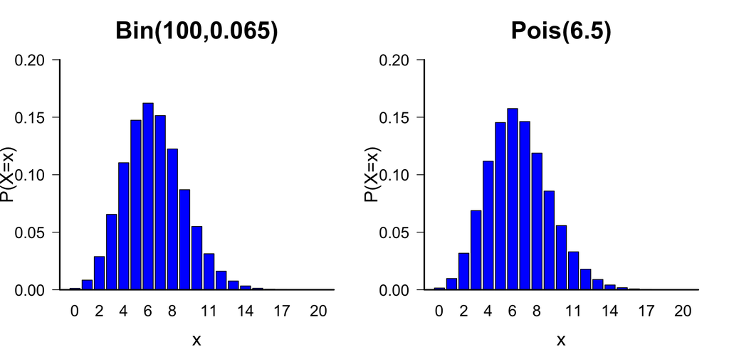

## Exemplo

A probabilidade de uma lâmpada se queimar ao ser ligada é \(1/100\). Numa instalação com 100 lâmpadas, qual a probabilidade de 2 lâmpadas se queimarem ao serem ligadas?

- No modelo Binomial: \(X\sim\mbox{Bin}(100,0.01)\)

\(P(X=2)= {\binom{100}{2}}(0.01)^{2}(0.99)^{100-2}\)=0.1849

- \(\lambda= np =100\times0.01=1\leq7\)
- No modelo Poisson: \(P(X=2)=\frac{e^{-1}(1)^{2}}{2!}\approx0.1839\)

## Distribuição de Poisson

Outro caso em que a distribuição de Poisson é utilizada:

- Considere a probabilidade de ocorrência de sucessos em um determinado intervalo.
- A probabilidade de ocorrência de um sucesso no intervalo é proporcional ao intervalo.
- A probabilidade de mais de um sucesso nesse intervalo é bastante pequena com relação à probabilidade de apenas um sucesso.

## Distribuição de Poisson

- Seja \(X\) o número de sucessos no intervalo, então:  
  \[P(X=x)=\frac{e^{-\lambda}\lambda^x}{x!} \,,\quad x=0,1,2,\ldots\]  
  onde \(\lambda\) é a esperança.
- Notação: \(X\sim\mbox{Poisson}(\lambda)\).

## Distribuição de Poisson

A distribuição de Poisson é muito usada na distribuição do número de:

- carros que passam por um cruzamento por minuto, durante uma certa hora do dia;
- número de mutações por unidade de comprimento na sequência de DNA;
- número de sinistros de uma companhia de seguros por semana;
- defeitos por unidade (\(m^3\), \(m^2\), \(m\), etc…) por peça fabricada;
- colônias de bactérias numa dada cultura por \(0.01 mm^2\), numa plaqueta de microscópio;
- mortes por ataque de coração por ano, em um certo bairro
- etc…

## Distribuição de Poisson

Para uma v.a. quantificando eventos raros, sob algumas suposições, podemos usar a distribuição de Poisson.

- Uma variável aleatória \(X\) tem distribuição de Poisson com parâmetro \(\lambda>0\), se sua função de probabilidade é dada por: \[P(X=x)=\frac{e^{-\lambda}\lambda^{x}}{x!}, \qquad x=0,1,2,...\]
- \(\lambda\) é chamado de taxa de ocorrência
- \(\mathbb E(X)=Var(X)=\lambda\)
- Notação: \(X\sim P(\lambda)\)

## Exemplo: Erros em um livro

Num livro de 800 páginas, há 800 erros de impressão. Qual a probabilidade de que uma página contenha pelo menos 3 erros?

\(X =\) número de erros por página

> Taxa de ocorrência: \(\lambda=1\)

\[ \begin{aligned} P(X\geq 3) &= 1-P(X<3)\\ &= 1-[P(X=0)+P(X=1)+P(X=2)]\\ &=1-\left\{ \frac{e^{-1}1^0}{0!} + \frac{e^{-1}1^1}{1!} +\frac{e^{-1}1^2}{2!} \right\}\\ &=0.08 \end{aligned} \]

## Exemplo: Mensagens no Facebook

Uma firma recebe 720 mensagens em sua página do Facebook durante as 8 horas de horário comercial. Qual a probabilidade de que em 6 minutos no horário comercial a firma receba pelo menos 4 mensagens no Facebook?

\[ \begin{aligned} 720\mbox{ mensagens} & \rightarrow 480 \mbox{ min}\\ \lambda &\rightarrow 6 \mbox{ min} \end{aligned} \]

Então, \(\lambda=9\) e

\[ \begin{aligned} P(X\geq 4)&= 1-P(X<4)=1-P(X\leq 3)\\ &= 1-\left[\frac{e^{-9}9^0}{0!}+\frac{e^{-9}9^1}{1!} +\frac{e^{-9}9^2}{2!} +\frac{e^{-9}9^3}{3!} \right]\\ &=0.979 \end{aligned} \]

## Exemplo: SAC

[figure not shown]

Numa central de SAC (serviço de atendimento ao consumidor) chegam \(300\) telefonemas por hora. Qual a probabilidade de que:

- num minuto não haja nenhuma chamada?
- em 2 minutos haja 2 chamadas?
- em \(t\) minutos não haja chamadas?

## Exemplo: SAC

\(X=\) número de chamadas por minuto.

- Taxa de ocorrência por minuto: \(\lambda= 300/60=5\)

\[ P(X= 0)=\frac{e^{-5}5^0}{0!}=0.0067 \]

> \(X=\) número de chamadas a cada 2 minutos.
- Taxa de ocorrência em 2 minutos: \(\lambda= 10\) \[P(X= 2)=\frac{e^{-10}10^2}{2!}=0.00227\]

> \(X=\) número de chamadas a cada \(t\) minutos.
- Taxa de ocorrência em \(t\) minutos: \(\lambda=5t\)

\[P(X=0)=\frac{e^{-5t}(5t)^0}{0!}=e^{-5t}\]

## Exemplo: Lâmpadas

A experiência mostra que de cada 400 lâmpadas, 2 se queimam ao serem ligadas. Qual a probabilidade de que numa instalação de:

- 600 lâmpadas, no mínimo 3 se queimem?
- 900 lâmpadas, exatamente 8 se queimem?

## Exemplo: Lâmpadas

\(X=\) número de lâmpadas que se queimam numa instalação de 600 lâmpadas.

> De 400, 2 se queimam, ou seja, de 200, 1 se queima.

> Taxa de ocorrência para 600 lâmpadas: \(\lambda= 600/200=3\)

> 600 lâmpadas, no mínimo 3 se queimem: \[ \begin{aligned} P(X\geq 3)&= \sum_{x=3}^{\infty}\frac{e^{-3}3^x}{x!}= 1-P(X<3)= \\ &= 1-[P(X=0)+P(X=1)+P(X=2)]\\ &= 1-\left[ \frac{e^{-3}3^0}{0!}+ \frac{e^{-3}3^1}{1!}+ \frac{e^{-3}3^2}{2!}\right]= 0.5768 \end{aligned} \]

## Exemplo: Lâmpadas

\(X=\) número de lâmpadas que se queimam numa instalação de 900 lâmpadas.

> Taxa de ocorrência para 900 lâmpadas: \(\lambda= 900/200=4.5\)

> 900 lâmpadas, 8 se queimem:

> \[P(X=8)= \frac{e^{-4.5}(4.5)^8}{8!}=0.0463\]

## Exemplo: Twitter

[figure not shown]

O número citações de uma certa conta do Twitter ocorre segundo uma distribuição de Poisson, com a média de oito citações por minuto.

> Determinar qual a probabilidade de que num minuto se tenha:
1. dez ou mais citações;
2. menos que nove citações;
3. entre sete (inclusive) e nove (exclusive) citações.

## Exemplo: Twitter

Sabemos que se \(X \sim \mbox{Poisson}(\lambda)\), então sua função de probabilidade é \[P(X=x) = \frac{e^{-\lambda} \lambda^x }{ x!}, \qquad x=0,1,\ldots\]

> Além disso, \(\mathbb{E}(X)=\lambda\).

> O enunciado diz *média de oito citações por minuto*, então a variável aleatória \(X\) = *número de citações por minuto* tem distribuição \(\mbox{Poisson}(8)\).
- A probabilidade de dez ou mais chamadas é dada por:

\[ \begin{aligned} P(X\geq10) & = 1-P(X<10) = 1-P(X\leq9)\\ &= 1-\displaystyle\sum_{k=0}^9 \frac{e^{-8}8^k}{k!} = 1- e^{-8} - \ldots - \displaystyle\frac{e^{-8}8^9}{9!} = 0.2833 \end{aligned} \]

## Exemplo: Twitter

- A probabilidade de termos menos que nove citações em um minuto é dada por:

\[P(X < 9) = P(X \leq 8) = e^{-8} + \ldots + \displaystyle\frac{e^{-8}8^8}{8!} = 0.5926\]

- A probabilidade de termos entre sete (inclusive) e nove (exclusive) citações em um minuto é dada por:

\[ \begin{aligned} P(7\leq X < 9)&=P(7\leq X \leq 8) = P(X=7)+P(X=8)\\ &=\displaystyle\frac{e^{-8}8^7}{7!}+\displaystyle\frac{e^{-8}8^8}{8!} = 0.2792 \end{aligned} \]

## Leituras

- Devore: capítulo 3.
- [Ross](http://www.sciencedirect.com/science/book/9780123743886): capítulo 5
- Magalhães: capítulo 3
- [OpenIntro](https://www.openintro.org/stat/textbook.php): seções 3.3, 3.4, 3.5.2

[figure not shown]

Slides produzidos pelos professores:

- Samara Kiihl
- Tatiana Benaglia
- Benilton Carvalho